# Reproducible Research assignment

José Castillo

3/27/2021

# Reproducible Research Programming Assignment 1

## Loading libraries and data

This is a Rmarkdown document for the first programming assignmet of the Reproducible Research course on the Data Science specialization course by the JH University

First of all, we load the libraries that we’re going to use for this assignmet

```r
library(readr)
library(ggplot2)
library(dplyr)
```

Then, we load the data. I’ve used the ‘read_csv’ function from the ‘readr’ library because it is faster (as it is coded in C) and because it loads the data directly into a tibble, which is very convinient.

```r
raw_data <- read_csv("./data/activity.csv")
```

## What is mean total number of steps taken per day?

To answer this question lets first calculate the total number of steps taken per day. We’ll use the powe of dplyr’s pipes:

```r
raw_data %>%
  group_by(date) %>%
  summarise(steps = sum(steps, na.rm = TRUE)) -> sum_data
```

Now we’re going to make an histogram with the total number of steps taken per day using the ggplot2 library

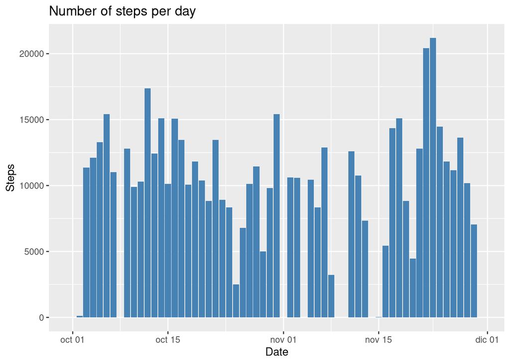

```r
ggplot(data = sum_data, aes(x = date, y = steps)) +
  geom_col(fill = "steelblue") +
  labs(title = "Number of steps per day", x = "Date", y = "Steps")
```

Now we’re gonna caclulate the mean and the median of the total of the total number of steps taken per day

```r
sum_data %>%
  summarise(mean = mean(steps), median = median(steps))
```

```
## # A tibble: 1 x 2
##    mean median
##   <dbl>  <dbl>
## 1 9354.  10395
```

We have a mean of 9354.23 steps taken per day and a median of 10395 steps.

## What is the average daily activity pattern?

Make a time series plot of the 5-minute interval (x-axis) and the average number of steps taken, averaged across all days (y-axis)

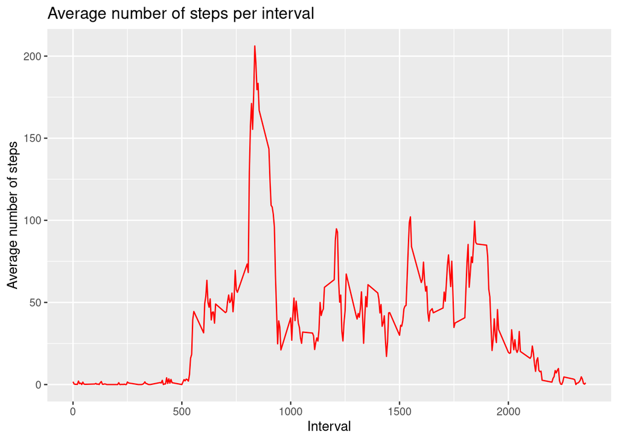

```r
raw_data %>%
  group_by(interval) %>%
  summarise(Mean = mean(steps, na.rm = TRUE)) -> DActivity

ggplot(DActivity, aes(interval, Mean)) + geom_line(col = "red") +
  labs(title = "Average number of steps per interval",
       x = "Interval", y = "Average number of steps")
```

## Which 5-minute interval, on average across all the days in the dataset, contains the maximum number of steps?

```r
DActivity[which.max(DActivity$Mean), ]$interval
```

```
## [1] 835
```

# Calculate and report the total number of missing values in the dataset

```r
sum(is.na(raw_data$steps))
```

```
## [1] 2304
```

# Create a strategy for imputing missing values in the dataset

```r
imputed_steps <- DActivity$Mean[match(raw_data$interval, DActivity$interval)]
```

# Create a new dataset that is equal to the original dataset but with the missing data filled in.

```r
imputed_data <- transform(raw_data,
                             steps = ifelse(is.na(raw_data$steps),
                                            yes = imputed_steps,
                                            no = raw_data$steps))

final_df <- aggregate(steps ~ date, imputed_data, sum)

names(final_df) <- c("date", "steps")

final_df <- data.frame(final_df)
```

# Make a histogram of the total number of steps taken each day and Calculate and report the mean and median total number of steps taken per day

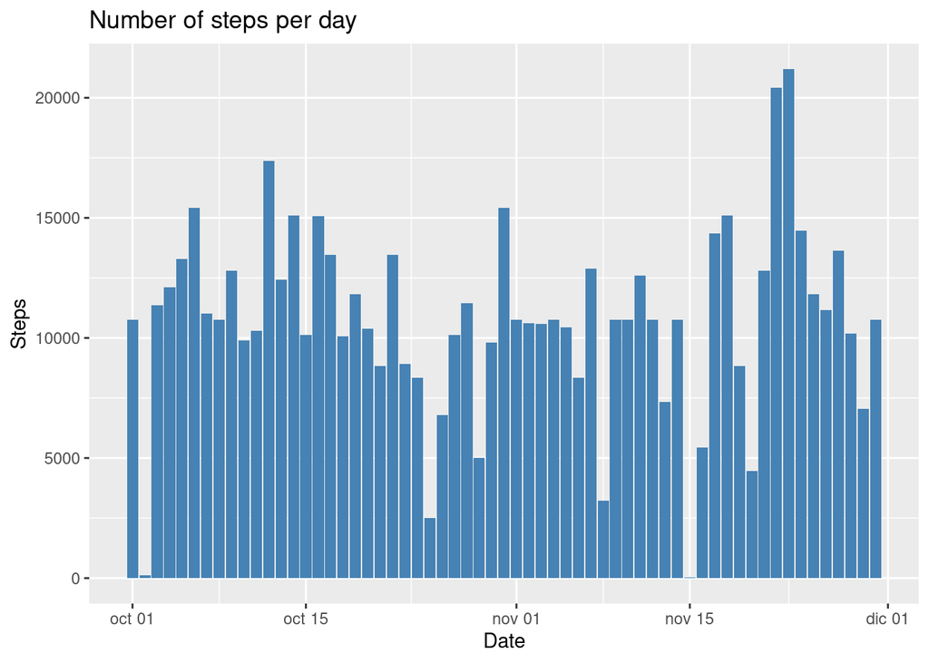

```r
ggplot(data = final_df, aes(x = date, y = steps)) +
  geom_col(fill = "steelblue") +
  labs(title = "Number of steps per day", x = "Date", y = "Steps")
```

# What is the impact of imputing the missing data on the mean and the median of steps taken per day?

```r
sum_data %>%
  summarise(mean = mean(steps), median = median(steps))
```

```
## # A tibble: 1 x 2
##    mean median
##   <dbl>  <dbl>
## 1 9354.  10395
```

```r
final_df %>%
  summarise(mean = mean(steps), median = median(steps))
```

```
##       mean   median
## 1 10766.19 10766.19
```

For the first data frame te mean and the median is 9354.23 and 10395 respectively and for the data set with the imputed missing values it is 10766.19 anbd 10766.19

## Are there differences in activity patterns between weekdays and weekends?

```r
raw_data$date <- as.Date(strptime(raw_data$date, format="%Y-%m-%d"))

raw_data$day <- sapply(raw_data$date, function(x) {
  if(weekdays(x) == "Saturday" | weekdays(x) == "Sunday")
  {y <- "Weekend"}
  else {y <- "Weekday"}
  y
})
```

[figure not shown]

```r
activity_day <-  aggregate(steps ~ interval + day, raw_data, mean, na.rm = TRUE)

ggplot(activity_day, aes(x = interval , y = steps, color = day)) +
  geom_line() + labs(title = "Differences between weekdays and weekends",
                     x = "days",
                     y = "steps") +
  facet_wrap(~day, ncol = 1, nrow=2) +
  scale_color_discrete(name = "Day Type")
```